# Travel Package Purchase Prediction - Amogh Antarkar

### Bagging Classifier

```
Training performance
    Accuracy    Recall  Precision        F1
0  0.992656  0.961059        1.0  0.980143
Testing performance
    Accuracy    Recall  Precision        F1
0  0.909527  0.672727   0.814978  0.737052
```

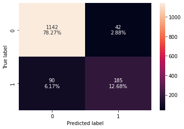

```python
bagging = BaggingClassifier(random_state=1)
bagging.fit(X_train,y_train)
confusion_matrix_sklearn(bagging, X_test, y_test)
bagging_model_train_perf=model_performance_classification_sklearn(bagging, X_train, y_train)
print("Training performance \n",bagging_model_train_perf)
bagging_model_test_perf=model_performance_classification_sklearn(bagging, X_test, y_test)
print("Testing performance \n",bagging_model_test_perf)
```

```
Training performance
    Accuracy    Recall  Precision        F1
0  0.992656  0.961059        1.0  0.980143
Testing performance
    Accuracy    Recall  Precision        F1
0  0.909527  0.672727   0.814978  0.737052
```

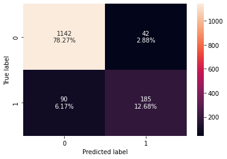

```python
confusion_matrix_sklearn(bagging, X_test, y_test)
bagging_model_train_perf=model_performance_classification_sklearn(bagging, X_train, y_train)
print("Training performance \n",bagging_model_train_perf)
bagging_model_test_perf=model_performance_classification_sklearn(bagging, X_test, y_test)
print("Testing performance \n",bagging_model_test_perf)
```

**Bagging Classifier with weighted decision tree**

```
Training performance
    Accuracy    Recall  Precision        F1
0  0.992949  0.962617        1.0  0.980952
Testing performance
    Accuracy    Recall  Precision        F1
0  0.907471  0.636364   0.833333  0.721649
```

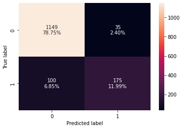

```python
bagging_wt = BaggingClassifier(base_estimator=DecisionTreeClassifier(criterion='gini',class_weight={0:0.18,1:0.82},random_state=1),random_state=1)
bagging_wt.fit(X_train,y_train)
confusion_matrix_sklearn(bagging_wt,X_test,y_test)
bagging_wt_model_train_perf=model_performance_classification_sklearn(bagging_wt,X_train,y_train)
print("Training performance \n",bagging_wt_model_train_perf)
bagging_wt_model_test_perf=model_performance_classification_sklearn(bagging_wt, X_test, y_test)
print("Testing performance \n",bagging_wt_model_test_perf)
```

```
Training performance
    Accuracy    Recall  Precision        F1
0  0.992949  0.962617        1.0  0.980952
Testing performance
    Accuracy    Recall  Precision        F1
0  0.907471  0.636364   0.833333  0.721649
```

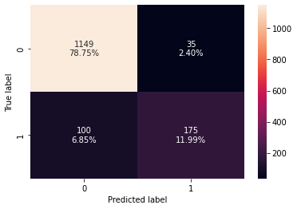

```python
from sklearn.linear_model import LogisticRegression
bagging_lr=BaggingClassifier(base_estimator=LogisticRegression(solver='liblinear',random_state=1,max_iter=1000),random_state=1)
bagging_lr.fit(X_train,y_train)
confusion_matrix_sklearn(bagging_wt,X_test,y_test)
bagging_wt_model_train_perf=model_performance_classification_sklearn(bagging_wt,X_train,y_train)
print("Training performance \n",bagging_wt_model_train_perf)
bagging_wt_model_test_perf=model_performance_classification_sklearn(bagging_wt, X_test, y_test)
print("Testing performance \n",bagging_wt_model_test_perf)
```

- Bagging classifier with a weighted decision tree is giving very good accuracy and prediction but is not able to generalize well on test data in terms of recall.

### Random Forest

```
Training performance
    Accuracy  Recall  Precision   F1
0       1.0     1.0        1.0  1.0
Testing performance
    Accuracy    Recall  Precision        F1
0  0.919808  0.621818   0.929348  0.745098
```

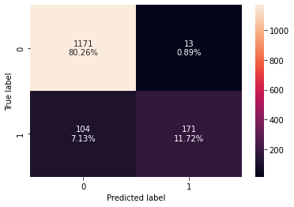

```python
rf = RandomForestClassifier(random_state=1)
rf.fit(X_train,y_train)
confusion_matrix_sklearn(rf,X_test,y_test)
rf_model_train_perf=model_performance_classification_sklearn(rf,X_train,y_train)
print("Training performance \n",rf_model_train_perf)
rf_model_test_perf=model_performance_classification_sklearn(rf,X_test,y_test)
print("Testing performance \n",rf_model_test_perf)
```

- Random Forest has performed well in terms of accuracy and precision, but it is not able to generalize well on the test data in terms of recall.

**Random forest with class weights**

```
Training performance
    Accuracy  Recall  Precision   F1
0       1.0     1.0        1.0  1.0
Testing performance
    Accuracy    Recall  Precision        F1
0  0.917066  0.603636   0.932584  0.732892
```

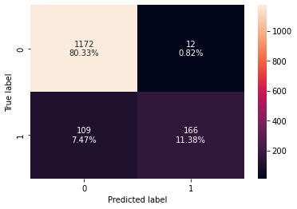

```python
rf_wt = RandomForestClassifier(class_weight={0:0.18,1:0.82}, random_state=1)
rf_wt.fit(X_train,y_train)
confusion_matrix_sklearn(rf_wt, X_test,y_test)
rf_wt_model_train_perf=model_performance_classification_sklearn(rf_wt, X_train,y_train)
print("Training performance \n",rf_wt_model_train_perf)
rf_wt_model_test_perf=model_performance_classification_sklearn(rf_wt, X_test,y_test)
print("Testing performance \n",rf_wt_model_test_perf)
```

- There is not much improvement in metrics of weighted random forest as compared to the unweighted random forest.